# Sosiaalisen median aktiivikäyttö ja syntyvyys

Antti J. Tanskanen, Elinkeinoelämän keskusliitto EK

1.3.2023

## Johdanto

Syntyneiden lasten määrä on Suomessa laskenut 61 000 lapsesta vuonna 2010 noin 50 300:ään vuonna 2017. Alkuvuoden 2018 luvuilla laskemalla vaikuttaa siltä että tämän vuoden syntyneden määrä jää ehkä 48 000:een ja hedelmällisyysluku 1,43:een alle vuoden 1973 pohjien. Laskeva trendi on jatkunut koko aikavälin 2010-2018, joten satunnaisvaihtelusta tuskin on kysymys. Osan syntyneiden lukumäärän laskusta selittää synnytysikäisten naisten lukumäärän pieneneminen, mutta ei läheskään kaikkea. Muiksi selityksiksi on tarjottu mm. työttömyyttä (Hiilamo, 2017) ja miesten heikkoa työsuhteeseen kiinnittymistä (Miettinen ja Jalovaara, 2015). Muissa maissa syntyvyyden laskun on arvioitu aiheutuvan mm. lapsikuolleisuuden vähenemisestä (Becker ja Barro, 1988), kaupungistumisesta (Martine et al., 2013) ja vanhuuseläkkeiden korkeammasta korvausasteesta (Boldrin et al., 2015). Sen lisäksi että työttömyys alentaisi syntyvyyttä, taloudellisten kriisien on myös havaittu lisänneen syntyvyyttä (Kohler ja Kohler, 2002).

Syntyneiden määrällä on viiveellä vaikutusta työikäisen väestön määrään, ja sitä kautta syntyvyyden laskulla on vaikutuksia mm. sosiaaliturvan rahoituksen kestävyyteen. Eläketurvakeskuksen laskelmien mukaan syntyvyyden lasku aiheuttaa työeläkemaksussa pitkällä aikavälillä useiden prosenttiyksiköiden nousupaineen (Tikanmäki, 2017). Myös Väestöntutkimuslaitos on analysoinut syitä syntyvyyden laskulle, mutta selkeätä syytä ei ole löytynyt (Rotkirch et al, 2017)

Tässä tutkimuksessa jatketaan aiemman harjoituksen mallilla ja kokeillaan miten hyvin ennuste toimii. Tämän lisäksi tutkimuksessa pyritään tarkastelemaan, onko sosiaalisen median aktiivikäytön lisääntymisellä kytkentää syntyvyyden laskuun.

## Aineisto

Verrattuna aiempiin harjoitelmiin, mukaan on otettu myös sosiaalisen median aktiivikäyttäjien osuus Tilastokeskuksen Viestintä- ja tietotekniikan käyttö-tutkimuksesta (“Seuraa jotain yhteisöpalvelua yleensä jatkuvasti kirjautuneena tai useasti päivässä”).

Aineiston perusteella ei voi tehdä kausaalisia päätelmiä, ainostaan assosiatiivisuutta koskevia. Tämä tietenkin rajoittaa tulkintamahdollisuuksia.

Tarkoituksena on avoimen, toistettavan tutkimuksen hengessä näyttää täsmällisesti mitä on tehty. Tästä syystä alkuperäinen aineisto (myös tämä työkirja koodeineen, Rmd-muotoisena; data Rdata-muodossa) on kokonaisuudessaan saatavissa osoitteesta https://github.com/ajtanskanen/Syntyvyyden-tekij-t

```
## # A tibble: 33 × 71
##    vuosi hedelmallisyysluku pienituloisuus_miehet_18_29 pienituloisuus_naiset_…¹
##    <dbl>              <dbl>                       <dbl>                    <dbl>
##  1  1990               1.78                         7.9                     11.4
##  2  1991               1.79                        10.9                     13.2
##  3  1992               1.85                        13.5                     13.9
##  4  1993               1.81                        12.7                     13.8
##  5  1994               1.85                        14.2                     16.6
##  6  1995               1.81                        15.9                     17.1
##  7  1996               1.76                        19.3                     20.3
##  8  1997               1.75                        18.2                     21.5
##  9  1998               1.7                         17.9                     22.4
## 10  1999               1.73                        18.2                     23.1
## # ℹ 23 more rows
## # ℹ abbreviated name: ¹pienituloisuus_naiset_18_29
## # ℹ 67 more variables: lapsikuolleisuus <dbl>, synnyttajien_keskiika <dbl>,
## #   sisempikaupunki <dbl>, ulompikaupunki <dbl>, kehyskaupunki <dbl>,
## #   maaseudulla <dbl>, avioituvuus_naiset_30_34 <dbl>,
## #   avioituvuus_naiset_25_29 <dbl>, eronneisuus_25_29 <dbl>,
## #   eronneisuus_30_34 <dbl>, kolmasaste_miehet_25_29 <dbl>, …
```

| vuosi | hedelmallisyysluku | pienituloisuus_miehet_18_29 | pienituloisuus_naiset_18_29 | lapsikuolleisuus | synnyttajien_keskiika | sisempikaupunki | ulompikaupunki | kehyskaupunki | maaseudulla | avioituvuus_naiset_30_34 | avioituvuus_naiset_25_29 | eronneisuus_25_29 | eronneisuus_30_34 | kolmasaste_miehet_25_29 | miehet_perusaste_25_29 | naiset_perusaste_25_29 | kolmasaste_naiset_25_29 | alypuhelin | some_25_34 | some_35_44 | työttömyys_miehet_25_34 | työttömyys_naiset_25_34 | työllisyysaste_miehet_25_34 | työllisyysaste_naiset_25_34 | työttömyys_miehet_35_44 | työttömyys_naiset_35_44 | työllisyysaste_miehet_35_44 | työllisyysaste_naiset_35_44 | ei_aviossa_30_34 | … |
| --- | --- | --- | --- | --- | --- | --- | --- | --- | --- | --- | --- | --- | --- | --- | --- | --- | --- | --- | --- | --- | --- | --- | --- | --- | --- | --- | --- | --- | --- | --- |
| 1990 | 1.782 | 7.9 | 11.4 | 0.005656 | 29.16007 | 29.07553 | 23.47094 | 9.400502 | 36.74539 | 51.40 | 87.50 | 24.5 | 20.9 | 22.20520 | 20.39246 | 14.71725 | 32.80953 | 0.0 | 0.000000 | 0.000000 | 2.7 | 2.1 | 90.7 | 80.6 | 2.7 | 1.5 | 92.1 | 88.3 | 0.3030237 | … |
| 1991 | 1.794 | 10.9 | 13.2 | 0.005804 | 29.17025 | 28.98024 | 23.76895 | 9.459372 | 36.58865 | 50.50 | 86.00 | 24.5 | 21.5 | 22.45398 | 20.71139 | 14.82640 | 33.94811 | 0.0 | 0.000000 | 0.000000 | 5.9 | 2.8 | 86.9 | 78.3 | 4.5 | 2.4 | 89.9 | 86.5 | 0.3038648 | … |
| 1992 | 1.847 | 13.5 | 13.9 | 0.005168 | 29.27384 | 28.86376 | 24.03029 | 9.515346 | 36.40213 | 49.50 | 81.10 | 25.3 | 21.8 | 22.90123 | 20.99995 | 14.83536 | 35.35189 | 0.0 | 0.000000 | 0.000000 | 12.6 | 7.7 | 78.8 | 72.5 | 10.6 | 6.0 | 83.6 | 81.4 | 0.3145014 | … |
| 1993 | 1.813 | 12.7 | 13.8 | 0.004299 | 29.36066 | 28.91661 | 24.22639 | 9.541993 | 36.18564 | 53.60 | 84.80 | 23.8 | 21.6 | 23.51026 | 21.11124 | 15.00487 | 36.81922 | 0.0 | 0.000000 | 0.000000 | 18.5 | 14.0 | 72.5 | 66.5 | 15.3 | 10.2 | 78.6 | 77.8 | 0.2870405 | … |
| 1994 | 1.847 | 14.2 | 16.6 | 0.004729 | 29.50438 | 29.13594 | 24.35195 | 9.520954 | 35.86900 | 54.20 | 84.10 | 24.9 | 23.4 | 24.20501 | 21.07767 | 15.20491 | 38.05622 | 0.0 | 0.000000 | 0.000000 | 20.8 | 16.5 | 70.8 | 64.0 | 16.6 | 12.7 | 77.0 | 76.3 | 0.2985374 | … |
| 1995 | 1.807 | 15.9 | 17.1 | 0.003858 | 29.68761 | 29.44644 | 24.41879 | 9.517619 | 35.48700 | 52.60 | 78.50 | 27.1 | 24.7 | 24.96074 | 21.02787 | 15.22944 | 39.31916 | 0.0 | 0.000000 | 0.000000 | 16.1 | 16.9 | 74.9 | 62.7 | 13.4 | 12.6 | 80.1 | 77.1 | 0.3233537 | … |
| 1996 | 1.764 | 19.3 | 20.3 | 0.003896 | 29.75513 | 29.69213 | 24.46521 | 9.524036 | 35.11732 | 55.40 | 78.50 | 27.7 | 23.5 | 25.61609 | 20.96593 | 15.16406 | 40.38486 | 0.0 | 0.000000 | 0.000000 | 15.1 | 16.4 | 75.6 | 63.5 | 12.4 | 11.1 | 80.4 | 78.4 | 0.3203035 | … |
| 1997 | 1.746 | 18.2 | 21.5 | 0.003859 | 29.85207 | 29.93875 | 24.52692 | 9.559717 | 34.74476 | 51.10 | 75.50 | 28.0 | 24.6 | 26.21721 | 20.83784 | 15.13552 | 41.65961 | 0.0 | 0.000000 | 0.000000 | 13.2 | 15.5 | 77.3 | 64.1 | 10.8 | 11.0 | 81.3 | 76.9 | 0.3373286 | … |
| 1998 | 1.700 | 17.9 | 22.4 | 0.004106 | 29.93836 | 30.16273 | 24.59814 | 9.606589 | 34.36780 | 52.70 | 74.80 | 27.0 | 26.1 | 26.66281 | 20.58038 | 14.71967 | 42.82898 | 0.0 | 0.000000 | 0.000000 | 11.6 | 13.0 | 78.6 | 66.6 | 10.2 | 8.6 | 83.0 | 79.1 | 0.3285642 | … |
| 1999 | 1.735 | 18.2 | 23.1 | 0.003643 | 29.94829 | 30.31594 | 24.74187 | 9.700420 | 34.18984 | 53.00 | 74.40 | 29.6 | 27.6 | 26.94710 | 19.89138 | 13.92199 | 43.48910 | 0.0 | 0.000000 | 0.000000 | 10.6 | 11.9 | 80.5 | 68.3 | 8.0 | 8.7 | 85.6 | 80.4 | 0.3450385 | … |
| 2000 | 1.729 | 16.7 | 21.7 | 0.003703 | 29.93065 | 30.46935 | 24.85905 | 9.785056 | 33.82567 | 59.10 | 76.90 | 29.3 | 26.3 | 26.62361 | 18.79471 | 13.07177 | 43.65627 | 0.0 | 0.100625 | 0.056875 | 9.8 | 12.1 | 82.3 | 68.6 | 7.7 | 9.8 | 84.9 | 79.3 | 0.3240190 | … |
| 2001 | 1.726 | 19.2 | 21.8 | 0.003222 | 29.93799 | 30.63816 | 25.00088 | 9.862325 | 33.45721 | 55.20 | 72.70 | 28.5 | 26.8 | 26.29434 | 17.89423 | 12.26555 | 43.67506 | 0.0 | 0.201250 | 0.113750 | 7.9 | 11.6 | 83.6 | 68.3 | 6.8 | 8.4 | 86.6 | 80.3 | 0.3320848 | … |
| 2002 | 1.718 | 21.0 | 22.4 | 0.003055 | 29.94876 | 30.68754 | 25.14669 | 9.953700 | 33.17434 | 59.70 | 79.40 | 27.9 | 27.2 | 26.25954 | 17.00937 | 11.46027 | 43.79083 | 0.0 | 0.402500 | 0.227500 | 8.8 | 9.6 | 82.6 | 72.8 | 7.1 | 6.8 | 85.5 | 82.2 | 0.3099909 | … |
| 2003 | 1.760 | 21.1 | 23.2 | 0.003122 | 29.99949 | 30.71711 | 25.27496 | 10.033216 | 32.92671 | 59.80 | 75.60 | 27.2 | 25.9 | 26.13405 | 16.52893 | 11.06241 | 43.56587 | 0.0 | 0.805000 | 0.455000 | 8.0 | 9.5 | 83.2 | 72.2 | 7.6 | 6.5 | 84.1 | 82.3 | 0.3080507 | … |
| 2004 | 1.800 | 20.9 | 24.8 | 0.003345 | 29.99861 | 30.68952 | 25.41501 | 10.148472 | 32.74767 | 69.10 | 81.10 | 27.8 | 25.2 | 25.54432 | 16.66686 | 10.78615 | 42.97749 | 0.0 | 1.610000 | 0.910000 | 9.3 | 9.1 | 82.7 | 70.0 | 7.2 | 7.8 | 85.6 | 79.2 | 0.2858804 | … |
| 2005 | 1.803 | 21.5 | 24.8 | 0.003029 | 29.98396 | 30.68325 | 25.53853 | 10.259743 | 32.52438 | 71.80 | 80.50 | 28.5 | 25.3 | 24.71607 | 17.44605 | 11.05609 | 41.88766 | 0.6 | 3.220000 | 1.820000 | 8.4 | 8.8 | 82.1 | 72.9 | 7.3 | 7.1 | 85.7 | 80.4 | 0.2842605 | … |
| 2006 | 1.837 | 20.7 | 23.2 | 0.002864 | 30.01663 | 30.68084 | 25.68068 | 10.369200 | 32.25263 | 69.10 | 77.00 | 28.3 | 24.3 | 24.04813 | 17.97995 | 11.17615 | 41.03960 | 1.6 | 5.060000 | 2.860000 | 7.2 | 8.2 | 83.3 | 73.3 | 5.3 | 6.7 | 87.1 | 81.2 | 0.2902197 | … |
| 2007 | 1.829 | 22.4 | 22.5 | 0.002735 | 30.03735 | 30.68097 | 25.82609 | 10.468855 | 31.99119 | 73.30 | 78.80 | 27.9 | 25.6 | 23.16005 | 18.81623 | 11.66691 | 40.02624 | 3.6 | 8.280000 | 4.680000 | 6.5 | 7.4 | 83.4 | 73.9 | 4.6 | 6.3 | 87.9 | 81.7 | 0.2759233 | … |
| 2008 | 1.846 | 22.9 | 23.7 | 0.002633 | 30.08387 | 30.80139 | 25.92121 | 10.552420 | 31.67928 | 75.10 | 80.50 | 29.3 | 26.2 | 23.49941 | 19.64056 | 12.02829 | 41.20856 | 6.6 | 11.500000 | 6.500000 | 5.5 | 6.2 | 86.3 | 73.9 | 4.2 | 5.8 | 88.8 | 83.1 | 0.2821314 | … |
| 2009 | 1.864 | 23.6 | 25.7 | 0.002722 | 30.07964 | 30.91861 | 25.98049 | 10.620027 | 31.41084 | 72.70 | 76.50 | 30.4 | 26.2 | 23.09035 | 19.79246 | 12.43646 | 40.38255 | 11.6 | 17.480000 | 9.880000 | 8.1 | 8.1 | 82.6 | 72.7 | 5.1 | 5.7 | 88.9 | 82.4 | 0.2953555 | … |
| 2010 | 1.870 | 24.5 | 25.1 | 0.002286 | 30.14016 | 31.01223 | 26.07021 | 10.670150 | 31.14255 | 73.60 | 75.90 | 30.7 | 26.8 | 23.57718 | 19.76929 | 12.64248 | 40.41627 | 18.6 | 21.160000 | 11.960000 | 9.4 | 8.5 | 81.1 | 71.1 | 7.1 | 5.7 | 86.1 | 82.5 | 0.2949428 | … |
| 2011 | 1.827 | 23.7 | 24.4 | 0.002341 | 30.25649 | 31.15617 | 26.14298 | 10.723169 | 30.84460 | 70.20 | 68.90 | 29.8 | 24.9 | 23.44754 | 19.77233 | 13.00261 | 40.28839 | 28.6 | 23.000000 | 13.000000 | 8.2 | 7.4 | 82.8 | 69.8 | 7.5 | 5.9 | 86.2 | 81.3 | 0.2980000 | … |
| 2012 | 1.801 | 24.2 | 22.9 | 0.002352 | 30.33253 | 31.34657 | 26.20222 | 10.796668 | 30.52489 | 66.40 | 69.60 | 29.5 | 25.4 | 23.62948 | 19.64206 | 13.29809 | 40.27121 | 38.6 | 21.000000 | 13.000000 | 7.9 | 7.5 | 81.6 | 70.6 | 5.9 | 4.9 | 86.5 | 82.5 | 0.3080499 | … |
| 2013 | 1.747 | 28.0 | 25.8 | 0.001726 | 30.43563 | 31.56901 | 26.24456 | 10.831568 | 30.19933 | 59.80 | 59.70 | 31.7 | 26.7 | 24.18749 | 19.07700 | 13.30760 | 40.54371 | 51.5 | 26.000000 | 18.000000 | 7.7 | 7.9 | 81.3 | 68.7 | 5.9 | 6.7 | 86.7 | 79.9 | 0.3507712 | … |
| 2014 | 1.710 | 30.6 | 27.5 | 0.002137 | 30.47105 | 31.82057 | 26.24797 | 10.884208 | 29.87697 | 57.60 | 56.70 | 33.4 | 28.2 | 24.39030 | 18.70532 | 13.60838 | 40.07974 | 61.5 | 33.000000 | 19.000000 | 9.6 | 7.8 | 78.8 | 69.7 | 6.4 | 6.3 | 85.2 | 79.5 | 0.3714540 | … |
| 2015 | 1.650 | 29.7 | 28.1 | 0.001718 | 30.59956 | 32.05831 | 26.30111 | 10.936146 | 29.50893 | 56.00 | 54.70 | 32.2 | 28.2 | 24.36150 | 18.81550 | 14.03869 | 39.29264 | 68.4 | 44.000000 | 27.000000 | 10.4 | 10.5 | 78.7 | 67.6 | 7.6 | 6.3 | 84.1 | 79.4 | 0.3733283 | … |
| 2016 | 1.567 | 26.2 | 27.1 | 0.001831 | 30.79952 | 32.24616 | 26.36616 | 10.977674 | 29.12863 | 53.80 | 52.60 | 31.2 | 27.5 | 24.52337 | 18.75504 | 14.06125 | 38.84403 | 74.9 | 55.000000 | 41.000000 | 9.6 | 9.7 | 79.3 | 67.6 | 6.6 | 7.5 | 85.5 | 79.1 | 0.3790357 | … |
| 2017 | 1.489 | 26.3 | 27.7 | 0.001955 | 30.90000 | 32.52178 | 26.39140 | 11.042493 | 28.75278 | 51.10 | 48.70 | 31.1 | 27.3 | 24.59459 | 18.22492 | 13.75754 | 38.85254 | 79.1 | 57.000000 | 41.000000 | 9.7 | 7.5 | 78.1 | 70.1 | 7.5 | 6.2 | 84.5 | 79.4 | 0.3969670 | … |
| 2018 | 1.407 | 28.5 | 30.3 | 0.002028 | 31.00000 | 32.79740 | 26.41663 | 11.107312 | 28.37693 | 46.60 | 45.30 | 28.0 | 27.9 | 25.62926 | 16.64358 | 12.07871 | 39.81549 | 80.0 | 53.000000 | 47.000000 | 9.2 | 9.7 | 80.2 | 69.2 | 5.5 | 5.9 | 86.3 | 81.3 | 0.4083963 | … |
| 2019 | 1.347 | 27.8 | 31.6 | 0.002050 | 31.20000 | 33.07302 | 26.44187 | 11.172132 | 28.00107 | 42.90 | 39.30 | 29.4 | 28.1 | 26.03882 | 16.47696 | 12.00570 | 40.01437 | 83.0 | 74.000000 | 45.202500 | 7.1 | 7.3 | 81.5 | 71.3 | 5.0 | 4.8 | 87.6 | 82.0 | 0.4503225 | … |
| 2020 | 1.370 | 25.1 | 28.7 | 0.001859 | 31.30000 | 33.34864 | 26.46711 | 11.236951 | 27.62522 | 42.50 | 36.30 | 29.8 | 28.9 | 26.83435 | 16.41897 | 12.01528 | 40.60123 | 87.0 | 85.000000 | 47.010600 | 7.3 | 7.1 | 81.1 | 73.0 | 4.2 | 3.8 | 87.9 | 82.1 | 0.4632686 | … |
| 2021 | 1.458 | 28.1 | 31.9 | 0.001828 | 31.60000 | 33.62426 | 26.49235 | 11.301770 | 27.24937 | 40.70 | 35.00 | 29.1 | 25.3 | 27.28595 | 16.66435 | 12.19444 | 41.21560 | 88.0 | 81.000000 | 73.000000 | 8.7 | 7.8 | 78.7 | 75.7 | 6.3 | 5.4 | 87.2 | 85.8 | 0.4729299 | … |
| 2022 | 1.316 | 28.1 | 31.9 | 0.001880 | 31.70000 | 33.81739 | 26.59043 | 11.281757 | 26.91324 | 38.08 | 31.48 | 23.6 | 23.2 | 27.73755 | 16.90974 | 12.37361 | 41.82997 | 88.0 | 80.000000 | 79.000000 | 5.3 | 6.8 | 79.7 | 79.3 | 6.0 | 4.1 | 88.8 | 85.6 | 0.4311708 | … |

# Faktorit

Faktorit

[figure not shown]

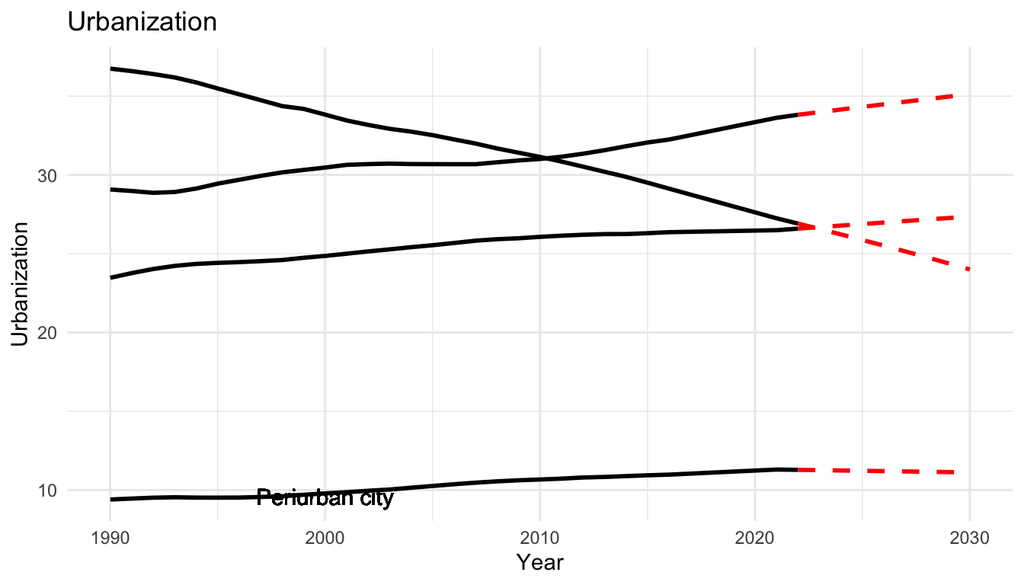

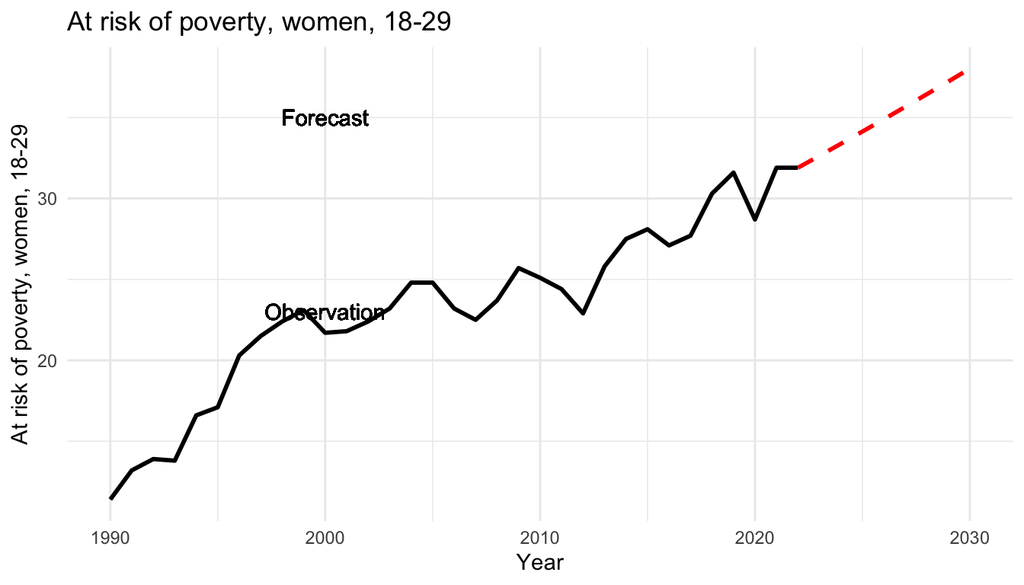

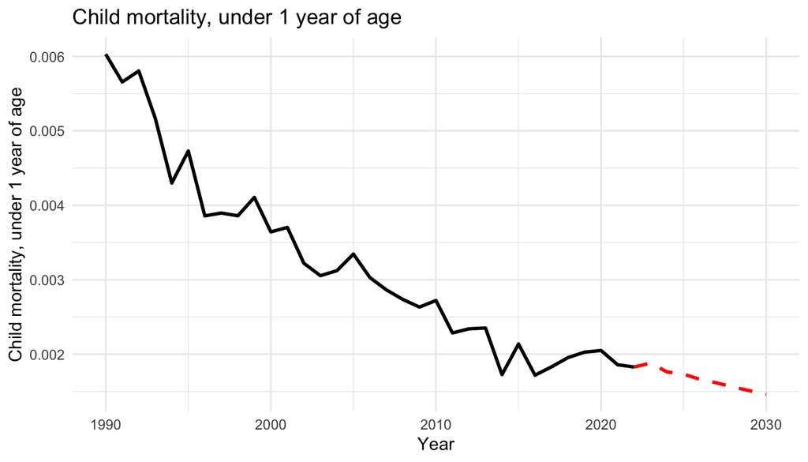

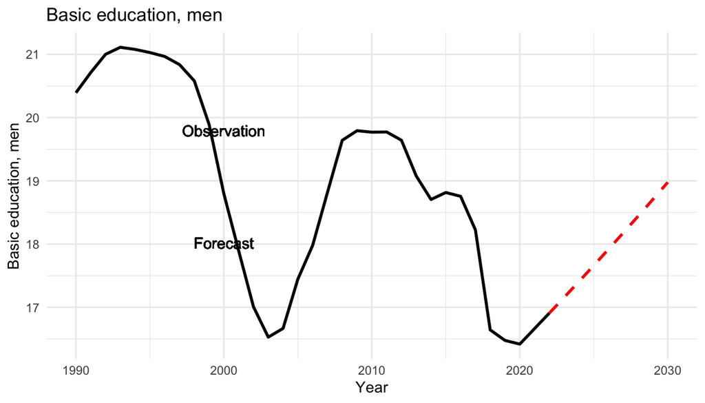

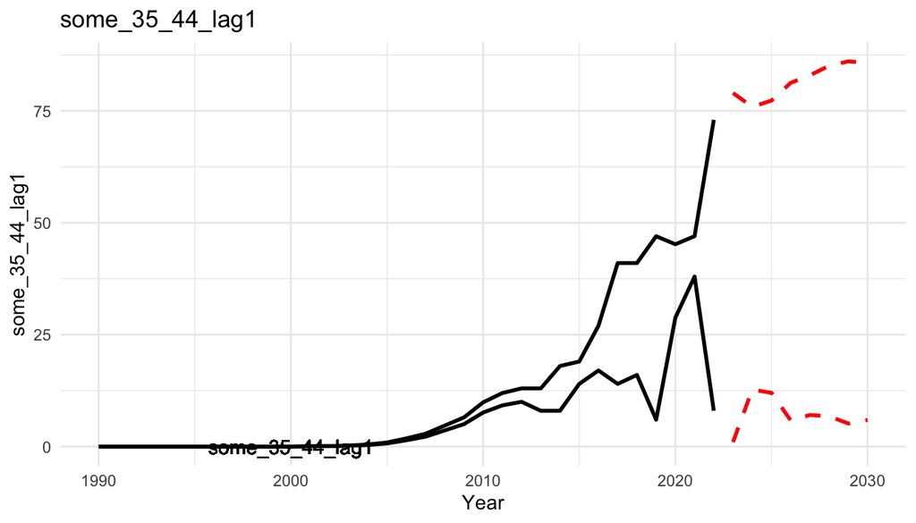

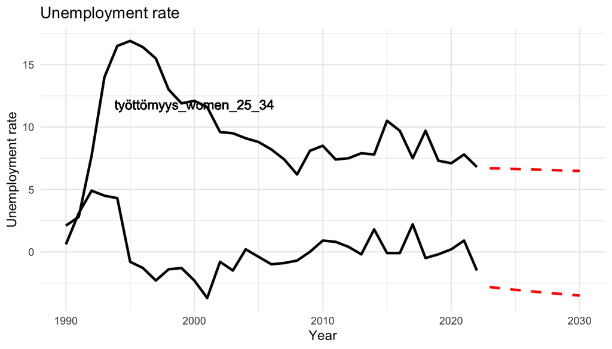

# Ennuste

tehdään ennuste seuraavaksi

Faktoriloadingit.

```
##                                  P(B != 0 | Y) model 1 model 2 model 3
## Intercept                                1.000   1.000   1.000   1.000
## lapsikuolleisuus                         0.111   0.000   0.000   0.000
## synnyttajien_keskiika                    0.293   0.000   1.000   0.000
## avioituvuus_naiset_25_29_lag1            0.244   0.000   0.000   1.000
## kehyskaupunki                            0.809   1.000   1.000   1.000
## sisempikaupunki                          0.364   0.000   0.000   0.000
## some_35_44_lag1                          0.258   0.000   0.000   0.000
## perusaste_diff_25_29_lag1                0.298   0.000   0.000   0.000
## ulompikaupunki                           0.232   0.000   0.000   0.000
## maaseudulla                              0.646   1.000   1.000   1.000
## pienituloisuus_naiset_18_29_lag1         0.166   0.000   0.000   0.000
## pienituloisuus_diff_18_29_lag1           0.170   0.000   0.000   0.000
## työttömyys_naiset_25_34                  0.191   0.000   0.000   0.000
## työttömyys_diff_25_34                    0.159   0.000   0.000   0.000
## miehet_perusaste_25_29                   0.573   1.000   1.000   1.000
## some_25_44_diff_lag1                     0.767   1.000   1.000   1.000
## kolmasaste_naiset_25_29_lag1             0.195   0.000   0.000   0.000
## kolmasaste_diff_25_29_lag1               0.803   1.000   1.000   1.000
## parittomia_30_34                         0.138   0.000   0.000   0.000
## BF                                          NA   1.000   0.228   0.209
## PostProbs                                   NA   0.070   0.016   0.014
## R2                                          NA   0.977   0.979   0.979
## dim                                         NA   6.000   7.000   7.000
## logmarg                                     NA  42.477  40.997  40.911
```

Regressiokertoimet todennäköisimmässä mallissa ovat

```
##
##  Marginal Posterior Summaries of Coefficients:
##
##  Using  HPM
##
##  Based on the top  1 models
##                                   post mean   post SD     post p(B != 0)
## Intercept                          1.7062424   0.0046467   1.0000000
## lapsikuolleisuus                   0.0000000   0.0000000   0.1114811
## synnyttajien_keskiika              0.0000000   0.0000000   0.2932062
## avioituvuus_naiset_25_29_lag1      0.0000000   0.0000000   0.2444077
## kehyskaupunki                      0.5511772   0.0430448   0.8091656
## sisempikaupunki                    0.0000000   0.0000000   0.3641880
## some_35_44_lag1                    0.0000000   0.0000000   0.2581867
## perusaste_diff_25_29_lag1          0.0000000   0.0000000   0.2975626
## ulompikaupunki                     0.0000000   0.0000000   0.2315678
## maaseudulla                        0.1703326   0.0105870   0.6463137
## pienituloisuus_naiset_18_29_lag1   0.0000000   0.0000000   0.1659224
## pienituloisuus_diff_18_29_lag1     0.0000000   0.0000000   0.1702681
## työttömyys_naiset_25_34            0.0000000   0.0000000   0.1912783
## työttömyys_diff_25_34              0.0000000   0.0000000   0.1590290
## miehet_perusaste_25_29             0.0174733   0.0045233   0.5726507
## some_25_44_diff_lag1               0.0031687   0.0009682   0.7671249
## kolmasaste_naiset_25_29_lag1       0.0000000   0.0000000   0.1946106
## kolmasaste_diff_25_29_lag1        -0.0472689   0.0027956   0.8031677
## parittomia_30_34                   0.0000000   0.0000000   0.1381737
```

```
##
##  Marginal Posterior Summaries of Coefficients:
##
##  Using  BMA
##
##  Based on the top  74954 models
##                                   post mean   post SD     post p(B != 0)
## Intercept                          1.6937273   0.0053467   1.0000000
## lapsikuolleisuus                   0.7048397  10.5633439   0.1054302
## synnyttajien_keskiika              0.0893618   0.1328818   0.4236742
## avioituvuus_naiset_25_29_lag1      0.0007816   0.0020619   0.1997686
## kehyskaupunki                      0.3698047   0.3251103   0.7009237
## sisempikaupunki                   -0.0917133   0.1389786   0.4389910
## some_35_44_lag1                   -0.0006025   0.0020270   0.3201540
## perusaste_diff_25_29_lag1          0.0189412   0.0301817   0.3879438
## ulompikaupunki                    -0.0472833   0.1367151   0.2767422
## maaseudulla                        0.0780739   0.1138419   0.5188192
## pienituloisuus_naiset_18_29_lag1  -0.0013723   0.0035366   0.1982664
## pienituloisuus_diff_18_29_lag1     0.0009549   0.0030671   0.1703478
## työttömyys_naiset_25_34           -0.0014042   0.0031803   0.2485668
## työttömyys_diff_25_34              0.0008800   0.0034917   0.1723886
## miehet_perusaste_25_29             0.0078637   0.0104976   0.4493488
## some_25_44_diff_lag1               0.0014892   0.0018791   0.4994007
## kolmasaste_naiset_25_29_lag1       0.0002596   0.0099531   0.2081415
## kolmasaste_diff_25_29_lag1        -0.0372601   0.0291555   0.7369350
## parittomia_30_34                  -0.0897983   0.3616939   0.1571800
```

```
##                  Length  Class  Mode
## postmean              19 -none- numeric
## postsd                19 -none- numeric
## probne0               19 -none- numeric
## conditionalmeans 1424126 -none- numeric
## conditionalsd    1424126 -none- numeric
## namesx                19 -none- character
## postprobs          74954 -none- numeric
## n.vars                 1 -none- numeric
## n.models               1 -none- numeric
## df                 74954 -none- numeric
## estimator              1 -none- character
```

```
##
##  Marginal Posterior Summaries of Coefficients:
##
##  Using  BMA
##
##  Based on the top  71030 models
##                                   post mean   post SD     post p(B != 0)
## Intercept                          1.7062424   0.0051071   1.0000000
## lapsikuolleisuus                   1.2092044  10.4861217   0.1114811
## synnyttajien_keskiika              0.0491871   0.1024433   0.2932062
## avioituvuus_naiset_25_29_lag1      0.0010182   0.0022762   0.2444077
## kehyskaupunki                      0.4170897   0.2815776   0.8091656
## sisempikaupunki                   -0.0638886   0.1188926   0.3641880
## some_35_44_lag1                   -0.0003684   0.0019105   0.2581867
## perusaste_diff_25_29_lag1          0.0120176   0.0250434   0.2975626
## ulompikaupunki                    -0.0321699   0.1090521   0.2315678
## maaseudulla                        0.1022265   0.1064409   0.6463137
## pienituloisuus_naiset_18_29_lag1  -0.0009691   0.0029314   0.1659224
## pienituloisuus_diff_18_29_lag1     0.0009113   0.0029310   0.1702681
## työttömyys_naiset_25_34           -0.0008124   0.0023756   0.1912783
## työttömyys_diff_25_34              0.0007592   0.0034853   0.1590290
## miehet_perusaste_25_29             0.0098552   0.0102119   0.5726507
## some_25_44_diff_lag1               0.0027520   0.0019382   0.7671249
## kolmasaste_naiset_25_29_lag1       0.0011355   0.0092743   0.1946106
## kolmasaste_diff_25_29_lag1        -0.0391364   0.0251162   0.8031677
## parittomia_30_34                  -0.0642343   0.3218554   0.1381737
```

```
##                  Length  Class  Mode
## postmean              19 -none- numeric
## postsd                19 -none- numeric
## probne0               19 -none- numeric
## conditionalmeans 1349570 -none- numeric
## conditionalsd    1349570 -none- numeric
## namesx                19 -none- character
## postprobs          71030 -none- numeric
## n.vars                 1 -none- numeric
## n.models               1 -none- numeric
## df                 71030 -none- numeric
## estimator              1 -none- character
```

```
##
##  Marginal Posterior Summaries of Coefficients:
##
##  Using  BMA
##
##  Based on the top  51897 models
##                                   post mean   post SD     post p(B != 0)
## Intercept                          1.7184375   0.0041143   1.0000000
## lapsikuolleisuus                  -0.1733515   9.2840740   0.1165956
## synnyttajien_keskiika              0.0140872   0.0556119   0.1495783
## avioituvuus_naiset_25_29_lag1      0.0026246   0.0029711   0.5231998
## kehyskaupunki                      0.2254890   0.2347591   0.6550892
## sisempikaupunki                   -0.0550422   0.0934493   0.3702255
## some_35_44_lag1                   -0.0041622   0.0038638   0.6111391
## perusaste_diff_25_29_lag1          0.0146383   0.0211499   0.4440327
## ulompikaupunki                    -0.0014667   0.0628881   0.2502672
## maaseudulla                        0.0436023   0.0849801   0.4474506
## pienituloisuus_naiset_18_29_lag1  -0.0004420   0.0018712   0.1212189
## pienituloisuus_diff_18_29_lag1     0.0006836   0.0024054   0.1706638
## työttömyys_naiset_25_34           -0.0001607   0.0013408   0.1342363
## työttömyys_diff_25_34              0.0050488   0.0066649   0.4490559
## miehet_perusaste_25_29             0.0048821   0.0074656   0.3833536
## some_25_44_diff_lag1               0.0045428   0.0019315   0.9287323
## kolmasaste_naiset_25_29_lag1      -0.0011040   0.0065039   0.1723314
## kolmasaste_diff_25_29_lag1        -0.0232618   0.0259912   0.5492161
## parittomia_30_34                  -0.0543143   0.3293928   0.1500870
```

```
##                  Length Class  Mode
## postmean             19 -none- numeric
## postsd               19 -none- numeric
## probne0              19 -none- numeric
## conditionalmeans 986043 -none- numeric
## conditionalsd    986043 -none- numeric
## namesx               19 -none- character
## postprobs         51897 -none- numeric
## n.vars                1 -none- numeric
## n.models              1 -none- numeric
## df                51897 -none- numeric
## estimator             1 -none- character
```

```
##
##  Marginal Posterior Summaries of Coefficients:
##
##  Using  BMA
##
##  Based on the top  57787 models
##                                   post mean   post SD     post p(B != 0)
## Intercept                          1.727e+00   3.657e-03   1.000e+00
## lapsikuolleisuus                   6.421e-02   7.211e+00   9.412e-02
## synnyttajien_keskiika             -2.917e-02   8.126e-02   1.983e-01
## avioituvuus_naiset_25_29_lag1      2.310e-03   2.744e-03   4.961e-01
## kehyskaupunki                      1.554e-01   1.836e-01   5.951e-01
## sisempikaupunki                   -8.386e-02   9.895e-02   5.227e-01
## some_35_44_lag1                   -4.787e-03   3.355e-03   7.456e-01
## perusaste_diff_25_29_lag1          6.691e-03   1.556e-02   3.081e-01
## ulompikaupunki                     2.055e-02   6.651e-02   2.775e-01
## maaseudulla                        4.157e-03   7.440e-02   4.020e-01
## pienituloisuus_naiset_18_29_lag1   1.333e-04   1.261e-03   8.293e-02
## pienituloisuus_diff_18_29_lag1     2.312e-04   1.648e-03   1.208e-01
## työttömyys_naiset_25_34           -1.359e-05   1.124e-03   1.292e-01
## työttömyys_diff_25_34              3.590e-03   5.562e-03   3.708e-01
## miehet_perusaste_25_29             7.583e-03   8.472e-03   5.235e-01
## some_25_44_diff_lag1               9.358e-04   1.586e-03   3.261e-01
## kolmasaste_naiset_25_29_lag1      -3.852e-03   9.363e-03   2.650e-01
## kolmasaste_diff_25_29_lag1        -1.894e-02   2.551e-02   4.874e-01
## parittomia_30_34                   2.649e-02   2.709e-01   1.174e-01
```

```
##                  Length  Class  Mode
## postmean              19 -none- numeric
## postsd                19 -none- numeric
## probne0               19 -none- numeric
## conditionalmeans 1097953 -none- numeric
## conditionalsd    1097953 -none- numeric
## namesx                19 -none- character
## postprobs          57787 -none- numeric
## n.vars                 1 -none- numeric
## n.models               1 -none- numeric
## df                 57787 -none- numeric
## estimator              1 -none- character
```

```
##
##  Marginal Posterior Summaries of Coefficients:
##
##  Using  BMA
##
##  Based on the top  58167 models
##                                   post mean   post SD     post p(B != 0)
## Intercept                          1.739e+00   3.494e-03   1.000e+00
## lapsikuolleisuus                   2.138e-01   6.555e+00   8.974e-02
## synnyttajien_keskiika             -1.371e-01   1.480e-01   5.484e-01
## avioituvuus_naiset_25_29_lag1      2.482e-03   2.532e-03   5.815e-01
## kehyskaupunki                      1.029e-01   1.838e-01   4.057e-01
## sisempikaupunki                   -5.695e-02   8.920e-02   3.908e-01
## some_35_44_lag1                   -3.067e-03   3.075e-03   5.885e-01
## perusaste_diff_25_29_lag1         -2.320e-03   1.653e-02   2.373e-01
## ulompikaupunki                     6.727e-02   8.827e-02   5.245e-01
## maaseudulla                        4.207e-03   6.516e-02   3.297e-01
## pienituloisuus_naiset_18_29_lag1   1.038e-04   1.212e-03   8.398e-02
## pienituloisuus_diff_18_29_lag1     4.777e-04   1.856e-03   1.362e-01
## työttömyys_naiset_25_34            3.409e-05   9.886e-04   1.139e-01
## työttömyys_diff_25_34              2.123e-03   4.546e-03   2.625e-01
## miehet_perusaste_25_29             1.408e-02   9.795e-03   7.733e-01
## some_25_44_diff_lag1               2.545e-04   1.153e-03   1.281e-01
## kolmasaste_naiset_25_29_lag1      -3.659e-03   9.779e-03   2.612e-01
## kolmasaste_diff_25_29_lag1        -2.119e-02   2.541e-02   5.590e-01
## parittomia_30_34                  -1.217e-02   2.650e-01   1.223e-01
```

```
##                  Length  Class  Mode
## postmean              19 -none- numeric
## postsd                19 -none- numeric
## probne0               19 -none- numeric
## conditionalmeans 1105173 -none- numeric
## conditionalsd    1105173 -none- numeric
## namesx                19 -none- character
## postprobs          58167 -none- numeric
## n.vars                 1 -none- numeric
## n.models               1 -none- numeric
## df                 58167 -none- numeric
## estimator              1 -none- character
```

```
##
##  Marginal Posterior Summaries of Coefficients:
##
##  Using  BMA
##
##  Based on the top  74346 models
##                                   post mean   post SD     post p(B != 0)
## Intercept                          1.752e+00   3.610e-03   1.000e+00
## lapsikuolleisuus                   4.423e-01   7.405e+00   1.088e-01
## synnyttajien_keskiika             -1.164e-01   1.506e-01   4.696e-01
## avioituvuus_naiset_25_29_lag1      2.321e-03   2.510e-03   5.563e-01
## kehyskaupunki                      1.419e-01   2.053e-01   5.000e-01
## sisempikaupunki                   -6.217e-02   9.231e-02   4.243e-01
## some_35_44_lag1                   -2.669e-03   3.009e-03   5.315e-01
## perusaste_diff_25_29_lag1         -2.014e-03   1.938e-02   2.900e-01
## ulompikaupunki                     5.468e-02   9.283e-02   4.697e-01
## maaseudulla                        1.419e-02   7.255e-02   3.754e-01
## pienituloisuus_naiset_18_29_lag1   1.664e-04   1.440e-03   1.052e-01
## pienituloisuus_diff_18_29_lag1     6.517e-04   2.144e-03   1.717e-01
## työttömyys_naiset_25_34            1.265e-06   1.099e-03   1.333e-01
## työttömyys_diff_25_34              1.832e-03   4.327e-03   2.533e-01
## miehet_perusaste_25_29             1.340e-02   1.069e-02   7.275e-01
## some_25_44_diff_lag1               2.697e-04   1.463e-03   1.194e-01
## kolmasaste_naiset_25_29_lag1      -3.784e-03   9.786e-03   2.767e-01
## kolmasaste_diff_25_29_lag1        -2.450e-02   2.522e-02   6.294e-01
## parittomia_30_34                   5.633e-03   3.096e-01   1.468e-01
```

```
##                  Length  Class  Mode
## postmean              19 -none- numeric
## postsd                19 -none- numeric
## probne0               19 -none- numeric
## conditionalmeans 1412574 -none- numeric
## conditionalsd    1412574 -none- numeric
## namesx                19 -none- character
## postprobs          74346 -none- numeric
## n.vars                 1 -none- numeric
## n.models               1 -none- numeric
## df                 74346 -none- numeric
## estimator              1 -none- character
```

```
##
##  Marginal Posterior Summaries of Coefficients:
##
##  Using  BMA
##
##  Based on the top  92745 models
##                                   post mean   post SD     post p(B != 0)
## Intercept                          1.7645714   0.0035747   1.0000000
## lapsikuolleisuus                   3.1798072  11.3226397   0.1775383
## synnyttajien_keskiika             -0.0473932   0.1070989   0.2846977
## avioituvuus_naiset_25_29_lag1      0.0015220   0.0021621   0.4269199
## kehyskaupunki                      0.1562521   0.1779380   0.6262642
## sisempikaupunki                   -0.1034867   0.0919622   0.6681282
## some_35_44_lag1                   -0.0016453   0.0024437   0.4074352
## perusaste_diff_25_29_lag1          0.0043486   0.0161423   0.2782017
## ulompikaupunki                     0.0269070   0.0855426   0.3615543
## maaseudulla                        0.0115644   0.0671014   0.3925703
## pienituloisuus_naiset_18_29_lag1   0.0002213   0.0015183   0.1259462
## pienituloisuus_diff_18_29_lag1     0.0003872   0.0017896   0.1573200
## työttömyys_naiset_25_34            0.0002337   0.0013725   0.1702736
## työttömyys_diff_25_34              0.0005248   0.0031904   0.1988771
## miehet_perusaste_25_29             0.0049732   0.0084997   0.3883217
## some_25_44_diff_lag1               0.0003790   0.0015721   0.1510227
## kolmasaste_naiset_25_29_lag1      -0.0085619   0.0124858   0.4570805
## kolmasaste_diff_25_29_lag1        -0.0333586   0.0261703   0.7610523
## parittomia_30_34                   0.0179415   0.3104452   0.1650005
```

```
##                  Length  Class  Mode
## postmean              19 -none- numeric
## postsd                19 -none- numeric
## probne0               19 -none- numeric
## conditionalmeans 1762155 -none- numeric
## conditionalsd    1762155 -none- numeric
## namesx                19 -none- character
## postprobs          92745 -none- numeric
## n.vars                 1 -none- numeric
## n.models               1 -none- numeric
## df                 92745 -none- numeric
## estimator              1 -none- character
```

```
## # A tibble: 41 × 71
##    vuosi hedelmallisyysluku pienituloisuus_miehet_18_29 pienituloisuus_naiset_…¹
##    <dbl>              <dbl>                       <dbl>                    <dbl>
##  1  1990               1.78                         7.9                     11.4
##  2  1991               1.79                        10.9                     13.2
##  3  1992               1.85                        13.5                     13.9
##  4  1993               1.81                        12.7                     13.8
##  5  1994               1.85                        14.2                     16.6
##  6  1995               1.81                        15.9                     17.1
##  7  1996               1.76                        19.3                     20.3
##  8  1997               1.75                        18.2                     21.5
##  9  1998               1.7                         17.9                     22.4
## 10  1999               1.73                        18.2                     23.1
## # ℹ 31 more rows
## # ℹ abbreviated name: ¹pienituloisuus_naiset_18_29
## # ℹ 67 more variables: lapsikuolleisuus <dbl>, synnyttajien_keskiika <dbl>,
## #   sisempikaupunki <dbl>, ulompikaupunki <dbl>, kehyskaupunki <dbl>,
## #   maaseudulla <dbl>, avioituvuus_naiset_30_34 <dbl>,
## #   avioituvuus_naiset_25_29 <dbl>, eronneisuus_25_29 <dbl>,
## #   eronneisuus_30_34 <dbl>, kolmasaste_miehet_25_29 <dbl>, …
```

ONESTEP

2018

2019

2020

2021

2022

datat

```
##  [1] 1990 1991 1992 1993 1994 1995 1996 1997 1998 1999 2000 2001 2002 2003 2004
## [16] 2005 2006 2007 2008 2009 2010 2011 2012 2013 2014 2015 2016 2017 2018 2019
## [31] 2020 2021 2022 2023 2024 2025 2026 2027 2028 2029 2030
```

```
## [1] 1.764305
```

```
##  [1]   NA   NA   NA   NA   NA   NA   NA   NA   NA   NA   NA   NA   NA   NA   NA
## [16]   NA   NA   NA   NA   NA   NA   NA   NA   NA   NA   NA   NA   NA 1.45
```

```
## [1] 1.791607
```

```
## [1] 1.800148
```

```
## [1] 1.801
```

```
## [1] 1.803932
```

```
## [1] 1.80166
```

datat

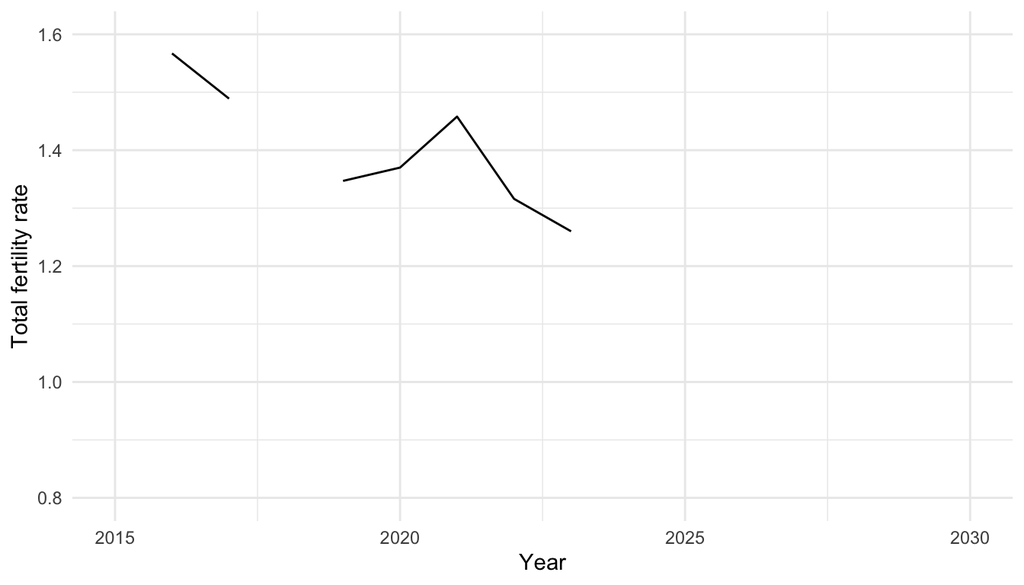

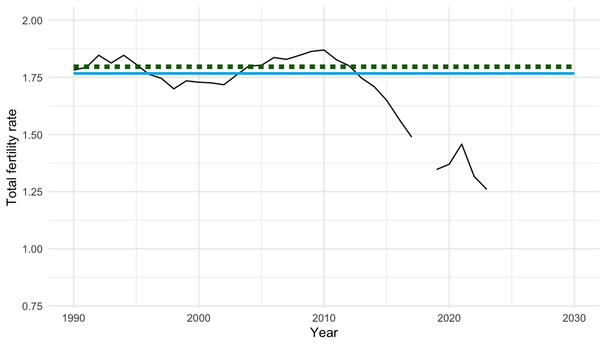

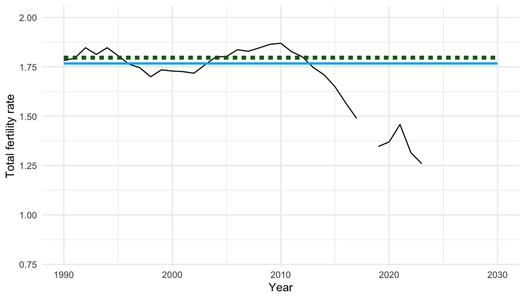

datat

```
##    year     lower   higher   ennuste   tfr
## 1  1990        NA       NA        NA 1.782
## 2  1991        NA       NA        NA 1.794
## 3  1992        NA       NA        NA 1.847
## 4  1993        NA       NA        NA 1.813
## 5  1994        NA       NA        NA 1.847
## 6  1995        NA       NA        NA 1.807
## 7  1996        NA       NA        NA 1.764
## 8  1997        NA       NA        NA 1.746
## 9  1998        NA       NA        NA 1.700
## 10 1999        NA       NA        NA 1.735
## 11 2000        NA       NA        NA 1.729
## 12 2001        NA       NA        NA 1.726
## 13 2002        NA       NA        NA 1.718
## 14 2003        NA       NA        NA 1.760
```

[output cut: 27 more lines]

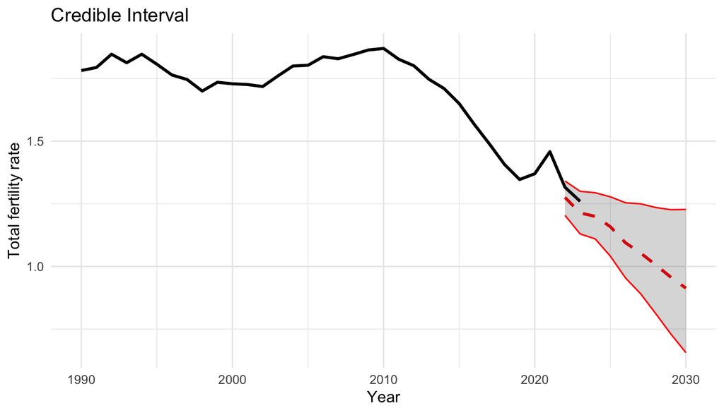

```
##    year     lower   higher   ennuste   tfr
## 1  1990        NA       NA        NA 1.782
## 2  1991        NA       NA        NA 1.794
## 3  1992        NA       NA        NA 1.847
## 4  1993        NA       NA        NA 1.813
## 5  1994        NA       NA        NA 1.847
## 6  1995        NA       NA        NA 1.807
## 7  1996        NA       NA        NA 1.764
## 8  1997        NA       NA        NA 1.746
## 9  1998        NA       NA        NA 1.700
## 10 1999        NA       NA        NA 1.735
## 11 2000        NA       NA        NA 1.729
## 12 2001        NA       NA        NA 1.726
## 13 2002        NA       NA        NA 1.718
## 14 2003        NA       NA        NA 1.760
```

[output cut: 27 more lines]

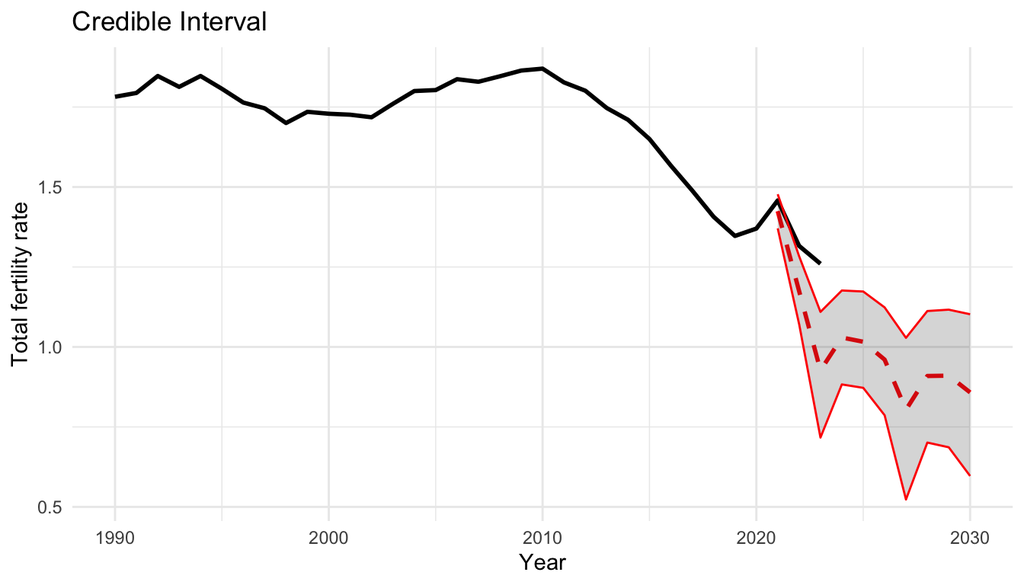

```
##    year     lower   higher  ennuste   tfr
## 1  1990        NA       NA       NA 1.782
## 2  1991        NA       NA       NA 1.794
## 3  1992        NA       NA       NA 1.847
## 4  1993        NA       NA       NA 1.813
## 5  1994        NA       NA       NA 1.847
## 6  1995        NA       NA       NA 1.807
## 7  1996        NA       NA       NA 1.764
## 8  1997        NA       NA       NA 1.746
## 9  1998        NA       NA       NA 1.700
## 10 1999        NA       NA       NA 1.735
## 11 2000        NA       NA       NA 1.729
## 12 2001        NA       NA       NA 1.726
## 13 2002        NA       NA       NA 1.718
## 14 2003        NA       NA       NA 1.760
```

[output cut: 27 more lines]

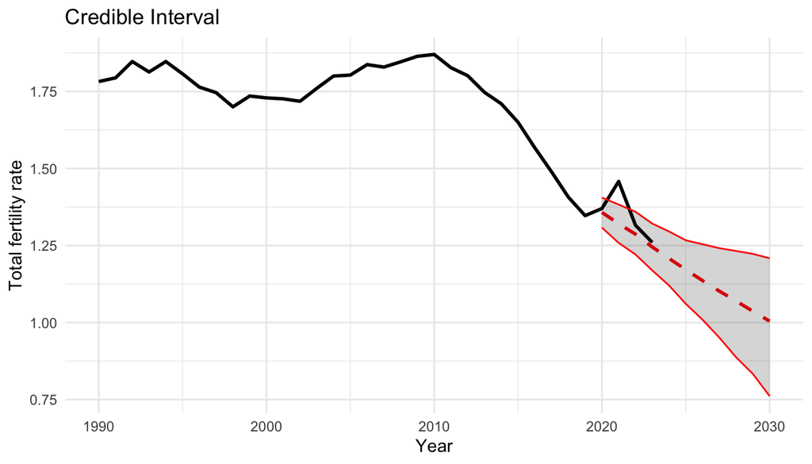

```
##    year     lower   higher   ennuste   tfr
## 1  1990        NA       NA        NA 1.782
## 2  1991        NA       NA        NA 1.794
## 3  1992        NA       NA        NA 1.847
## 4  1993        NA       NA        NA 1.813
## 5  1994        NA       NA        NA 1.847
## 6  1995        NA       NA        NA 1.807
## 7  1996        NA       NA        NA 1.764
## 8  1997        NA       NA        NA 1.746
## 9  1998        NA       NA        NA 1.700
## 10 1999        NA       NA        NA 1.735
## 11 2000        NA       NA        NA 1.729
## 12 2001        NA       NA        NA 1.726
## 13 2002        NA       NA        NA 1.718
## 14 2003        NA       NA        NA 1.760
```

[output cut: 27 more lines]

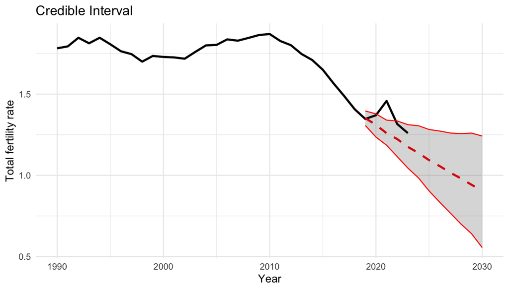

```
##    year     lower   higher   ennuste   tfr
## 1  1990        NA       NA        NA 1.782
## 2  1991        NA       NA        NA 1.794
## 3  1992        NA       NA        NA 1.847
## 4  1993        NA       NA        NA 1.813
## 5  1994        NA       NA        NA 1.847
## 6  1995        NA       NA        NA 1.807
## 7  1996        NA       NA        NA 1.764
## 8  1997        NA       NA        NA 1.746
## 9  1998        NA       NA        NA 1.700
## 10 1999        NA       NA        NA 1.735
## 11 2000        NA       NA        NA 1.729
## 12 2001        NA       NA        NA 1.726
## 13 2002        NA       NA        NA 1.718
## 14 2003        NA       NA        NA 1.760
```

[output cut: 27 more lines]

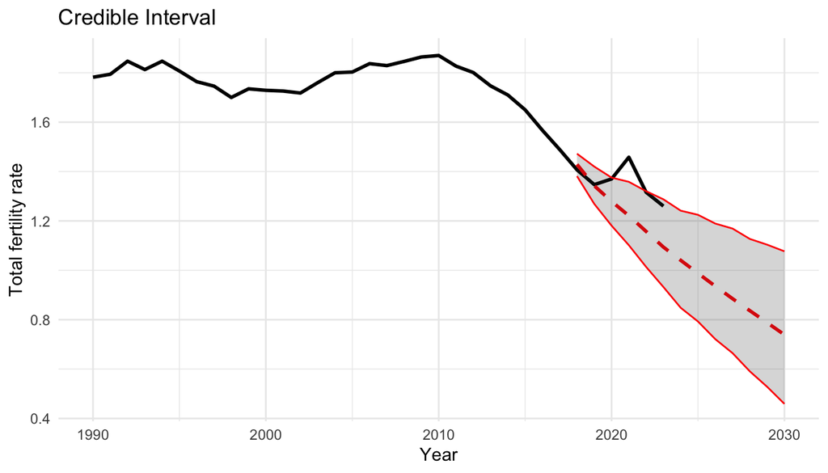

```
##    year     lower   higher   ennuste   tfr
## 1  1990        NA       NA        NA 1.782
## 2  1991        NA       NA        NA 1.794
## 3  1992        NA       NA        NA 1.847
## 4  1993        NA       NA        NA 1.813
## 5  1994        NA       NA        NA 1.847
## 6  1995        NA       NA        NA 1.807
## 7  1996        NA       NA        NA 1.764
## 8  1997        NA       NA        NA 1.746
## 9  1998        NA       NA        NA 1.700
## 10 1999        NA       NA        NA 1.735
## 11 2000        NA       NA        NA 1.729
## 12 2001        NA       NA        NA 1.726
## 13 2002        NA       NA        NA 1.718
## 14 2003        NA       NA        NA 1.760
```

[output cut: 27 more lines]

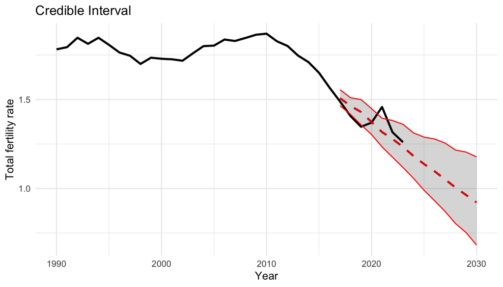